## Tarea 3

Programa Experto en Inteligencia Artificial con Python  
ML2000 - Métodos No Supervisados  
Estudiante: Natalia Bonilla Villalobos.

# Menú

- Ejercicio 1
- Ejercicio 2

```python
!pip install prince
```

```python
!pip install scikit-learn-extra
```

```python
# !pip install 'numpy<2'
```

```python
import numpy as np
import pandas as pd
import seaborn as sns
import matplotlib.pyplot as plt
from math import pi
from prince import PCA as PCA_Prince
from sklearn.preprocessing import StandardScaler
from sklearn.preprocessing import MinMaxScaler
from sklearn.cluster import KMeans
from sklearn_extra.cluster import KMedoids
from sklearn.metrics import silhouette_score
from itertools import cycle
from scipy.spatial.distance import pdist, squareform
from scipy.cluster.hierarchy import ward, single, complete, average
from scipy.cluster.hierarchy import dendrogram, linkage, fcluster
from sklearn.preprocessing import MinMaxScaler
from abc import ABC, abstractmethod
```

# Ejercicio 1

[80 puntos] Utilice el conjunto de datos `StressLevel.csv`. Este conjunto contiene información obtenida de una encuesta a estudiantes universitarios, con el objetivo de identificar factores asociados al estrés académico. La tabla cuenta con N filas (estudiantes) y 20 variables descritas a continuación:

- **Factores psicológicos:**
  - `anxiety_level`: Nivel de ansiedad reportado. Escala numerica discreta (mayores valores = más ansiedad).
  - `self_esteem`: Nivel de autoestima. Escala numerica discreta (valores altos = mayor autoestima).
  - `mental_health_history`: Antecedentes de salud mental (0 = No, 1 = Sí). Variable categórica binaria.
  - `depression`: Puntaje de síntomas depresivos. Numerica discreta (valores altos = mayor depresión).
- **Factores fisiológicos:**
  - `headache`: Frecuencia de dolores de cabeza. Categórica ordinal (0 = nunca, 5 = muy frecuente).
  - `blood_pressure`: Nivel de presión arterial. Categórica ordinal (1 = baja, 2 = normal, 3 = alta).
  - `sleep_quality`: Calidad del sueño. Categórica ordinal (0 = muy mala, 5 = muy buena).
  - `breathing_problem`: Presencia de problemas respiratorios. Categórica ordinal (0 = nunca, 5 = muy frecuente).
- **Factores ambientales:**
  - `noise_level`: Nivel de ruido en el entorno. Categórica ordinal (0 = bajo, 5 = muy alto).
  - `living_conditions`: Condiciones de vida del estudiante. Categórica ordinal (0 = muy malas, 5 = muy buenas).
  - `safety`: Percepción de seguridad en el entorno. Categórica ordinal (0 = nada seguro, 5 = muy seguro).
  - `basic_needs`: Grado de satisfacción de necesidades básicas (alimentación, vivienda). Categórica ordinal (0 = insatisfechas, 5 = totalmente satisfechas).
- **Factores académicos:**
  - `academic_performance`: Confianza en el rendimiento académico. Categórica ordinal (0 = muy baja, 5 = muy alta).
  - `study load`: Percepción de la carga académica. Categórica ordinal (0 = muy ligera, 5 = muy pesada).
  - `teacher_student_relationship`: Calidad de la relación con los profesores. Categórica ordinal (0 = muy mala, 5 = muy buena).
  - `future_career_concerns`: Preocupación por la carrera futura. Categórica ordinal (0 = nada preocupado, 5 = muy preocupado).
- **Factores sociales:**
  - `social_support`: Nivel de apoyo social percibido. Categórica ordinal (0 = muy bajo, 5 = muy alto).
  - `peer_pressure`: Presión ejercida por los pares. Categórica ordinal (0 = nula, 5 = muy alta).
  - `extracurricular_activities`: Participación en actividades extracurriculares. Categórica ordinal (0 = nula, 5 = muy alta).
  - `bullying`: Presencia de acoso escolar. Categórica ordinal (0 = nunca, 5 = muy frecuente).
- **Variable objetivo:**
  - `stress_type`: Tipo de estrés que experimenta principalmente el estudiante. Variable categórica con tres clases posibles: No Stress = 0, Eustress = 1, Distress = 2.

**Realice lo siguiente:**

- a) Convierta todas las variables a numérica.
- b) Usando 10 ejecuciones del método k-medias genere el Codo de Jambu. Se estabiliza en algún momento la inercia inter-clases?
- c) Usando 10 ejecuciones del método k-medias genere el Silhouette. Se estabiliza en algún momento la inercia inter-clases?
- d) Genere el Clustering Jerárquico con 3 clusters. (Utilice los parámetros que considere más adecuados). Muestre la inercia, el gráfico de barras y el de radar.
- e) Genere k-Medias con 3 clusters. (Utilice los parámetros que considere más adecuados). Muestre la inercia, el gráfico de barras y el de radar.
- f ) Genere k-Medoides con 3 clusters. (Utilice los parámetros que considere más adecuados). Muestre la inercia, el gráfico de barras y el de radar.
- g) Brinde una característica de cada cluster utilizando el gráfico radar. Solo para uno de los gráficos generados

↑ Volver al Menú

## Parte 1

- a) Convierta todas las variables a numérica.

```python
df = pd.read_csv('StressLevel.csv')
df.head()
```

|  | anxiety_level | self_esteem | mental_health_history | depression | headache | blood_pressure | sleep_quality | breathing_problem | noise_level | living_conditions | ... | basic_needs | academic_performance | study_load | teacher_student_relationship | future_career_concerns | social_support | peer_pressure | extracurricular_activities | bullying | stress_level |
| --- | --- | --- | --- | --- | --- | --- | --- | --- | --- | --- | --- | --- | --- | --- | --- | --- | --- | --- | --- | --- | --- |
| 0 | 14 | 20 | 0 | 11 | 2 | 1 | 2 | 4 | 2 | 3 | ... | 2 | 3 | 2 | 3 | 3 | 2 | 3 | 3 | 2 | 1 |
| 1 | 15 | 8 | 1 | 15 | 5 | 3 | 1 | 4 | 3 | 1 | ... | 2 | 1 | 4 | 1 | 5 | 1 | 4 | 5 | 5 | 2 |
| 2 | 12 | 18 | 1 | 14 | 2 | 1 | 2 | 2 | 2 | 2 | ... | 2 | 2 | 3 | 3 | 2 | 2 | 3 | 2 | 2 | 1 |
| 3 | 16 | 12 | 1 | 15 | 4 | 3 | 1 | 3 | 4 | 2 | ... | 2 | 2 | 4 | 1 | 4 | 1 | 4 | 4 | 5 | 2 |
| 4 | 16 | 28 | 0 | 7 | 2 | 3 | 5 | 1 | 3 | 2 | ... | 3 | 4 | 3 | 1 | 2 | 1 | 5 | 0 | 5 | 1 |

5 rows × 21 columns

```python
df.shape
```

```
(1100, 21)
```

```python
df_codificado = df.copy()
```

```python
# mental_health_history =  0:No, 1:Si
df_codificado[['mental_health_history_no','mental_health_history_si']] = pd.get_dummies(df_codificado['mental_health_history'], dtype=int)
df_codificado[['mental_health_history', 'mental_health_history_si','mental_health_history_no']].head()
```

|  | mental_health_history | mental_health_history_si | mental_health_history_no |
| --- | --- | --- | --- |
| 0 | 0 | 0 | 1 |
| 1 | 1 | 1 | 0 |
| 2 | 1 | 1 | 0 |
| 3 | 1 | 1 | 0 |
| 4 | 0 | 0 | 1 |

```python
#No Stress = 0, Eustress = 1, Distress = 2.
df_codificado[['stress_type_no_stress','stress_type_eustress', 'stress_type_distress']] = pd.get_dummies(df_codificado['stress_level'], dtype=int)
df_codificado[['stress_level', 'stress_type_no_stress','stress_type_eustress', 'stress_type_distress']].head(7)
```

|  | stress_level | stress_type_no_stress | stress_type_eustress | stress_type_distress |
| --- | --- | --- | --- | --- |
| 0 | 1 | 0 | 1 | 0 |
| 1 | 2 | 0 | 0 | 1 |
| 2 | 1 | 0 | 1 | 0 |
| 3 | 2 | 0 | 0 | 1 |
| 4 | 1 | 0 | 1 | 0 |
| 5 | 2 | 0 | 0 | 1 |
| 6 | 0 | 1 | 0 | 0 |

```python
df_codificado.columns
```

```
Index(['anxiety_level', 'self_esteem', 'mental_health_history', 'depression',
       'headache', 'blood_pressure', 'sleep_quality', 'breathing_problem',
       'noise_level', 'living_conditions', 'safety', 'basic_needs',
       'academic_performance', 'study_load', 'teacher_student_relationship',
       'future_career_concerns', 'social_support', 'peer_pressure',
       'extracurricular_activities', 'bullying', 'stress_level',
       'mental_health_history_no', 'mental_health_history_si',
       'stress_type_no_stress', 'stress_type_eustress',
       'stress_type_distress'],
      dtype='object')
```

```python
df_codificado = df_codificado.drop(columns=['mental_health_history', 'stress_level'], axis=1)
```

```python
df_codificado.shape
```

```
(1100, 24)
```

## Parte 2

- b) Usando 10 ejecuciones del método k-medias genere el Codo de Jambu. Se estabiliza en algún momento la inercia inter-clases?

```python
escalar = StandardScaler()
datos_escalados = escalar.fit_transform(df_codificado)
datos_escalados = pd.DataFrame(datos_escalados)
datos_escalados.columns = df_codificado.columns
datos_escalados.index = df_codificado.index
datos_escalados.head()
```

|  | anxiety_level | self_esteem | depression | headache | blood_pressure | sleep_quality | breathing_problem | noise_level | living_conditions | safety | ... | future_career_concerns | social_support | peer_pressure | extracurricular_activities | bullying | mental_health_history_no | mental_health_history_si | stress_type_no_stress | stress_type_eustress | stress_type_distress |
| --- | --- | --- | --- | --- | --- | --- | --- | --- | --- | --- | --- | --- | --- | --- | --- | --- | --- | --- | --- | --- | --- |
| 0 | 0.480208 | 0.248612 | -0.201393 | -0.360741 | -1.418416 | -0.426445 | 0.890211 | -0.488949 | 0.430695 | 0.186924 | ... | 0.229550 | 0.112839 | 0.186334 | 0.164249 | -0.403377 | 0.985559 | -0.985559 | -0.716287 | 1.439662 | -0.710484 |
| 1 | 0.643746 | -1.093590 | 0.316508 | 1.768859 | 0.981981 | -1.072574 | 0.890211 | 0.264334 | -1.357096 | -0.524551 | ... | 1.537869 | -0.841952 | 0.888277 | 1.575763 | 1.557071 | -1.014653 | 1.014653 | -0.716287 | -0.694608 | 1.407491 |
| 2 | 0.153131 | 0.024912 | 0.187033 | -0.360741 | -1.418416 | -0.426445 | -0.538282 | -0.488949 | -0.463200 | 0.186924 | ... | -0.424609 | 0.112839 | 0.186334 | -0.541508 | -0.403377 | -1.014653 | 1.014653 | -0.716287 | 1.439662 | -0.710484 |
| 3 | 0.807284 | -0.646189 | 0.316508 | 1.058992 | 0.981981 | -1.072574 | 0.175964 | 1.017616 | -0.463200 | -0.524551 | ... | 0.883709 | -0.841952 | 0.888277 | 0.870006 | 1.557071 | -1.014653 | 1.014653 | -0.716287 | -0.694608 | 1.407491 |
| 4 | 0.807284 | 1.143414 | -0.719293 | -0.360741 | 0.981981 | 1.511942 | -1.252529 | 0.264334 | -0.463200 | 0.898398 | ... | -0.424609 | -0.841952 | 1.590220 | -1.953023 | 1.557071 | 0.985559 | -0.985559 | -0.716287 | 1.439662 | -0.710484 |

5 rows × 24 columns

```python
kmedias = KMeans(n_clusters=3, n_init=10, max_iter=100, algorithm="elkan")
kmedias.fit(datos_escalados)
```

```
KMeans(algorithm='elkan', max_iter=100, n_clusters=3, n_init=10)
```

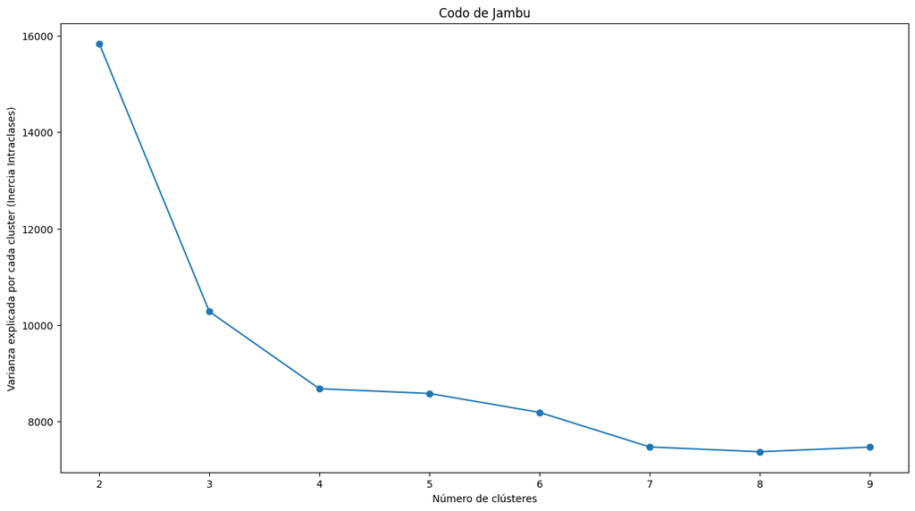

```python
cantidad_clusters = range(2, 10)
lista_kmedias = [KMeans(n_clusters=i).fit(datos_escalados) for i in cantidad_clusters]
varianza = [lista_kmedias[i].inertia_ for i in range(len(lista_kmedias))]

#Gráfico
fig, ax = plt.subplots(figsize=(15, 8))
no_print = ax.plot(cantidad_clusters, varianza, 'o-')
no_print = ax.set_xlabel('Número de clústeres')
no_print = ax.set_ylabel('Varianza explicada por cada cluster (Inercia Intraclases)')
no_print = ax.set_title('Codo de Jambu')
plt.show()
```

## Parte 3

- c) Usando 10 ejecuciones del método k-medias genere el Silhouette. Se estabiliza en algún momento la inercia inter-clases?

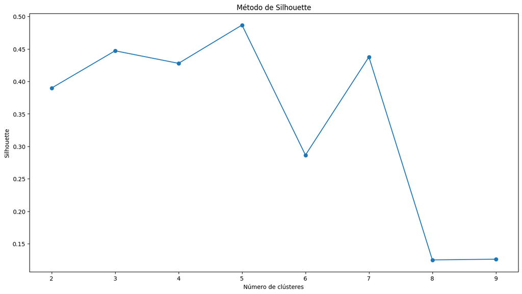

```python
cantidad_clusters = range(2, 10)
lista_kmedias = [KMeans(n_clusters=i).fit(datos_escalados) for i in cantidad_clusters]
silhouette = [silhouette_score(datos_escalados, lista_kmedias[i].labels_) for i in range(len(lista_kmedias))]

fig, ax = plt.subplots(figsize = (15,8))
no_print = ax.plot(cantidad_clusters, silhouette, 'o-')
no_print = ax.set_xlabel("Número de clústeres")
no_print = ax.set_ylabel("Silhouette")
no_print = ax.set_title('Método de Silhouette')
plt.show()
```

## Parte 4

- d) Genere el Clustering Jerárquico con 3 clusters. (Utilice los parámetros que considere más adecuados). Muestre la inercia, el gráfico de barras y el de radar.

**Definiendo la Inercia**

```python
def inercias_cj(df_scalar, nombre_linkage, df_dummy, nombre_metric, nombre_inercia):
  distancia = pdist(df_scalar, metric = nombre_metric)
  agregacion = nombre_linkage(distancia)
  grupos = fcluster(agregacion, 4, criterion = 'maxclust')
  grupos = grupos - 1
  datos_cluster = df_codificado.copy()
  datos_cluster["cluster"] = grupos
  promedios = datos_cluster.groupby("cluster").mean()

  if nombre_inercia.lower() == 'intra':
    intra_clase = 0
    for i in range(df_dummy.shape[0]):
      intra_clase = intra_clase + np.sum((df_dummy.iloc[i, :] - promedios.iloc[grupos[i], :]) ** 2)
    return round(intra_clase, 3)
  elif nombre_inercia.lower() == 'inter':
    promedios_total = df_codificado.mean()
    inter_clase = 0
    for i in range(promedios.shape[0]):
      n = np.sum(grupos == i)
      inter_clase = inter_clase + (n * np.sum((promedios_total - promedios.iloc[i, :]) ** 2))
    return round(inter_clase, 3)
  elif nombre_inercia.lower() == 'total':
    promedios_total = df_dummy.mean()
    inercia_total = 0
    for i in range(df_dummy.shape[0]):
      inercia_total = inercia_total + np.sum((df_dummy.iloc[i, :] - promedios_total) ** 2)
    return round(inercia_total, 3)
  else:
    print("Revise los parametros de la función")


def imprimir_inercia_detallada(df_cod_scaled, df_cod, linkages, distancias, nombre_linkages):
  tipos_inercia = ['intra', 'inter', 'total']

  for distancia_nombre in distancias:
    print(f"\n======= Tipo de Inercia | linkage | distancia =======")

    for i, linkage_obj in enumerate(linkages):
      linkage_nombre = nombre_linkages[i]

      for tipo_inercia in tipos_inercia:
        valor_inercia =  inercias_cj(df_cod_scaled, linkage_obj, df_cod, distancia_nombre, nombre_inercia=tipo_inercia)
        print(f"Inercia Clase-{tipo_inercia.capitalize()} | {linkage_nombre} | {distancia_nombre.capitalize()}: {valor_inercia}")
      print()
```

```python
# Buscar MÍNIMA inercia intra-clase (dentro del cluster)
# Buscar MÁXIMA inercia inter-clase (entre clusters)
linkages = [ward, single, complete, average]
nombre_linkages = ['Ward', 'Single', 'Complete', 'Average']
distancias = ['euclidean', 'chebyshev', 'canberra']

imprimir_inercia_detallada(datos_escalados, df_codificado, linkages, distancias, nombre_linkages)
```

```
======= Tipo de Inercia | linkage | distancia =======
Inercia Clase-Intra | Ward | Euclidean: 71368.519
Inercia Clase-Inter | Ward | Euclidean: 157075.931
Inercia Clase-Total | Ward | Euclidean: 228444.45

Inercia Clase-Intra | Single | Euclidean: 227634.802
Inercia Clase-Inter | Single | Euclidean: 809.648
Inercia Clase-Total | Single | Euclidean: 228444.45

Inercia Clase-Intra | Complete | Euclidean: 90889.947
Inercia Clase-Inter | Complete | Euclidean: 137554.503
Inercia Clase-Total | Complete | Euclidean: 228444.45

Inercia Clase-Intra | Average | Euclidean: 118119.756
Inercia Clase-Inter | Average | Euclidean: 110324.694
Inercia Clase-Total | Average | Euclidean: 228444.45


======= Tipo de Inercia | linkage | distancia =======
Inercia Clase-Intra | Ward | Chebyshev: 75741.568
Inercia Clase-Inter | Ward | Chebyshev: 152702.882
Inercia Clase-Total | Ward | Chebyshev: 228444.45

Inercia Clase-Intra | Single | Chebyshev: 227401.582
Inercia Clase-Inter | Single | Chebyshev: 1042.868
Inercia Clase-Total | Single | Chebyshev: 228444.45

Inercia Clase-Intra | Complete | Chebyshev: 114628.491
Inercia Clase-Inter | Complete | Chebyshev: 113815.959
Inercia Clase-Total | Complete | Chebyshev: 228444.45

Inercia Clase-Intra | Average | Chebyshev: 227619.511
Inercia Clase-Inter | Average | Chebyshev: 824.939
Inercia Clase-Total | Average | Chebyshev: 228444.45


======= Tipo de Inercia | linkage | distancia =======
Inercia Clase-Intra | Ward | Canberra: 71368.519
Inercia Clase-Inter | Ward | Canberra: 157075.931
Inercia Clase-Total | Ward | Canberra: 228444.45

Inercia Clase-Intra | Single | Canberra: 228067.573
Inercia Clase-Inter | Single | Canberra: 376.877
Inercia Clase-Total | Single | Canberra: 228444.45

Inercia Clase-Intra | Complete | Canberra: 88906.157
Inercia Clase-Inter | Complete | Canberra: 139538.293
Inercia Clase-Total | Complete | Canberra: 228444.45

Inercia Clase-Intra | Average | Canberra: 85550.342
Inercia Clase-Inter | Average | Canberra: 142894.108
Inercia Clase-Total | Average | Canberra: 228444.45
```

**Ward: Euclidean y Canberra son mejores opciones**

```python
mejor_agregacion = ward(pdist(datos_escalados, "euclidean"))
grupos_definitivos = fcluster(mejor_agregacion, 3, criterion='maxclust') - 1

print("=== CLUSTERS DEFINITIVOS ===")
print("Distribución de puntos por cluster:")
print(pd.Series(grupos_definitivos).value_counts().sort_index())

# Añadir clusters al dataframe
df_con_clusters = df_codificado.copy()
df_con_clusters['cluster'] = grupos_definitivos
```

```
=== CLUSTERS DEFINITIVOS ===
Distribución de puntos por cluster:
0    300
1    301
2    499
Name: count, dtype: int64
```

**Código de Barras**

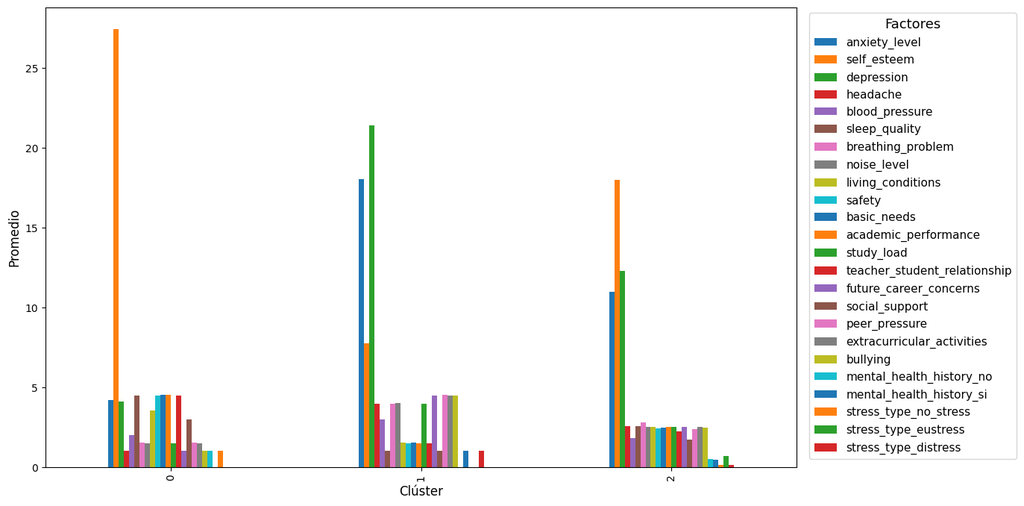

```python
def graficar_barras_promedios(promedios, xlabel='Clúster', ylabel='Promedio', title='Factores'):
  fig, ax = plt.subplots(figsize=(13, 8))  # tamaño por defecto
  no_print = promedios.plot(kind='bar', ax=ax)
  no_print = ax.set_xlabel(xlabel, fontsize=12)
  no_print = ax.set_ylabel(ylabel, fontsize=12)
  no_print = ax.legend(title=title, title_fontsize=13, fontsize=11, loc='upper right', bbox_to_anchor=(1.3, 1))
  plt.show()
promedios_clusters = df_con_clusters.groupby('cluster').mean()
graficar_barras_promedios(promedios_clusters)
```

**Gráfico tipo radar**

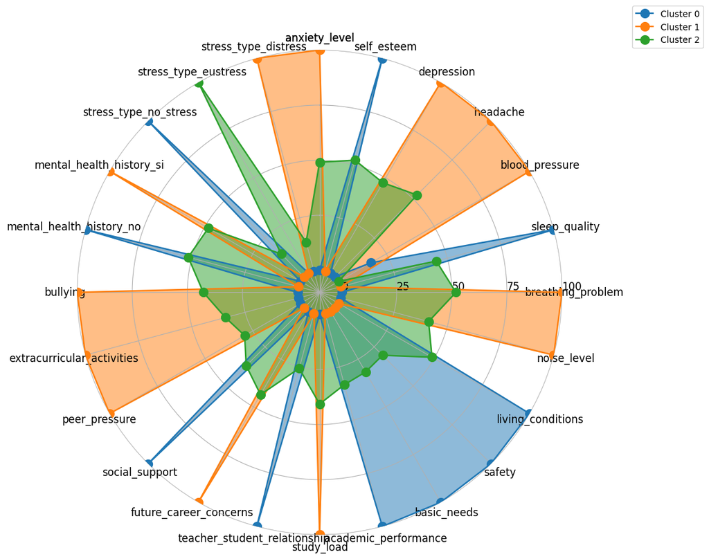

```python
def graficar_radar_promedios(promedios):
    # Escalado 0-100
    scaler = MinMaxScaler()
    escalar_promedios = pd.DataFrame(
        scaler.fit_transform(promedios),
        columns=promedios.columns,
        index=promedios.index
    )
    escalar_promedios = escalar_promedios * 100
    columnas = escalar_promedios.columns
    N = len(columnas)
    # Ángulos (cerrando el polígono)
    theta = np.linspace(0, 2 * np.pi, N, endpoint=False)
    theta = np.concatenate([theta, [theta[0]]])
    fig, ax = plt.subplots(figsize=(10, 10), subplot_kw={"projection": "polar"})
    no_print = ax.set_theta_zero_location("N")
    no_print = ax.set_theta_direction(-1)
    no_print = ax.set_rlabel_position(90)
    no_print = ax.spines["polar"].set_zorder(1)
    no_print = ax.spines["polar"].set_color("lightgrey")
    # Trazar cada clúster
    for fila in escalar_promedios.index:
        valores = escalar_promedios.loc[fila, columnas].values.tolist()
        valores = valores + [valores[0]]  # cerrar polígono
        no_print = ax.plot(theta, valores, linewidth=1.75, linestyle="solid",
                           label=f"Cluster {fila}", marker="o", markersize=10)
        no_print = ax.fill(theta, valores, alpha=0.50)
    # Ejes y leyendas
    no_print = plt.yticks([0, 25, 50, 75, 100], ["0", "25", "50", "75", "100"], color="black", size=12)
    no_print = plt.ylim(-10, 100)
    no_print = plt.xticks(theta, columnas.to_list() + [columnas[0]], color="black", size=12)
    no_print = plt.legend(loc="upper right", bbox_to_anchor=(1.3, 1.1))
    plt.show()
graficar_radar_promedios(promedios_clusters)
```

## Parte 5

- e) Genere k-Medias con 3 clusters. (Utilice los parámetros que considere más adecuados). Muestre la inercia, el gráfico de barras y el de radar.

> El método de **kmeans** permite definir el algoritmo, estos pueden ser:

> `lloyd` `elkan`

**Modelo**

```python
# lloyd o elkan
kmedias = KMeans(n_clusters=3, n_init=10, max_iter=100, algorithm="elkan")
kmedias.fit(datos_escalados)
```

```
KMeans(algorithm='elkan', max_iter=100, n_clusters=3, n_init=10)
```

**Clusters**

```python
grupos = kmedias.labels_
grupos
```

```
array([2, 0, 2, ..., 1, 0, 0], dtype=int32)
```

**Unir cluster -> df**

```python
datos_cluster = df.copy()
datos_cluster["cluster"] = grupos
datos_cluster.head(7)
```

|  | anxiety_level | self_esteem | mental_health_history | depression | headache | blood_pressure | sleep_quality | breathing_problem | noise_level | living_conditions | ... | academic_performance | study_load | teacher_student_relationship | future_career_concerns | social_support | peer_pressure | extracurricular_activities | bullying | stress_level | cluster |
| --- | --- | --- | --- | --- | --- | --- | --- | --- | --- | --- | --- | --- | --- | --- | --- | --- | --- | --- | --- | --- | --- |
| 0 | 14 | 20 | 0 | 11 | 2 | 1 | 2 | 4 | 2 | 3 | ... | 3 | 2 | 3 | 3 | 2 | 3 | 3 | 2 | 1 | 2 |
| 1 | 15 | 8 | 1 | 15 | 5 | 3 | 1 | 4 | 3 | 1 | ... | 1 | 4 | 1 | 5 | 1 | 4 | 5 | 5 | 2 | 0 |
| 2 | 12 | 18 | 1 | 14 | 2 | 1 | 2 | 2 | 2 | 2 | ... | 2 | 3 | 3 | 2 | 2 | 3 | 2 | 2 | 1 | 2 |
| 3 | 16 | 12 | 1 | 15 | 4 | 3 | 1 | 3 | 4 | 2 | ... | 2 | 4 | 1 | 4 | 1 | 4 | 4 | 5 | 2 | 0 |
| 4 | 16 | 28 | 0 | 7 | 2 | 3 | 5 | 1 | 3 | 2 | ... | 4 | 3 | 1 | 2 | 1 | 5 | 0 | 5 | 1 | 2 |
| 5 | 20 | 13 | 1 | 21 | 3 | 3 | 1 | 4 | 3 | 2 | ... | 2 | 5 | 2 | 5 | 1 | 4 | 4 | 5 | 2 | 0 |
| 6 | 4 | 26 | 0 | 6 | 1 | 2 | 4 | 1 | 1 | 4 | ... | 5 | 1 | 4 | 1 | 3 | 2 | 2 | 1 | 0 | 1 |

7 rows × 22 columns

**Centro Clusters**

```python
promedios = datos_cluster.groupby("cluster").mean()
promedios
```

| cluster | anxiety_level | self_esteem | mental_health_history | depression | headache | blood_pressure | sleep_quality | breathing_problem | noise_level | living_conditions | ... | basic_needs | academic_performance | study_load | teacher_student_relationship | future_career_concerns | social_support | peer_pressure | extracurricular_activities | bullying | stress_level |
| --- | --- | --- | --- | --- | --- | --- | --- | --- | --- | --- | --- | --- | --- | --- | --- | --- | --- | --- | --- | --- | --- |
| 0 | 17.855769 | 7.923077 | 0.996795 | 21.214744 | 3.939103 | 3.000000 | 1.016026 | 3.919872 | 3.987179 | 1.525641 | ... | 1.538462 | 1.503205 | 3.932692 | 1.493590 | 4.455128 | 0.983974 | 4.451923 | 4.394231 | 4.407051 | 1.987179 |
| 1 | 4.182724 | 27.438538 | 0.000000 | 4.172757 | 1.000000 | 2.003322 | 4.488372 | 1.514950 | 1.468439 | 3.531561 | ... | 4.514950 | 4.504983 | 1.485050 | 4.465116 | 1.003322 | 2.993355 | 1.524917 | 1.501661 | 1.006645 | 0.000000 |
| 2 | 10.965092 | 18.119097 | 0.474333 | 12.188912 | 2.523614 | 1.767967 | 2.583162 | 2.772074 | 2.521561 | 2.527721 | ... | 2.486653 | 2.515400 | 2.484600 | 2.264887 | 2.509240 | 1.770021 | 2.381930 | 2.507187 | 2.466119 | 0.977413 |

3 rows × 21 columns

**Inercias**

```python
def incercia_km(datos):
  promedios_total = datos.mean()
  inercia_total = 0
  for i in range(datos.shape[0]):
    inercia_total = inercia_total + np.sum((datos.iloc[i, :] - promedios_total) ** 2)

  intra_clase = 0
  for i in range(datos.shape[0]):
    intra_clase = intra_clase + np.sum((datos.iloc[i, :] - promedios.iloc[grupos[i], :]) ** 2)

  inter_clase = 0
  for i in range(promedios.shape[0]):
    n = np.sum(grupos == i)
    inter_clase = inter_clase + (n * np.sum((promedios_total - promedios.iloc[i, :]) ** 2))

  return (f"intra_clase: {round(intra_clase, 2)}, "
          f"inter_clase: {round(inter_clase,2)}, "
          f"inercia_total: {round(inercia_total,2)}")
```

```python
incercia_km(df)
```

```
'intra_clase: 76013.72, inter_clase: 152164.55, inercia_total: 228178.27'
```

**Gráfico de Barras**

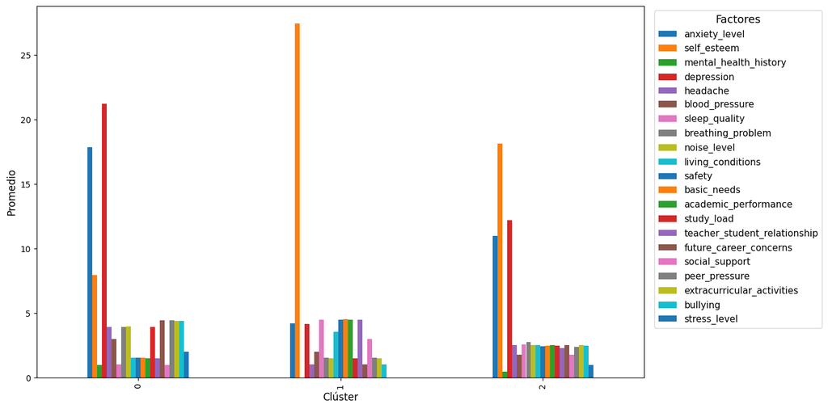

```python
graficar_barras_promedios(promedios, "Clúster", "Promedio", "Factores")
```

**MinMaxScaler**

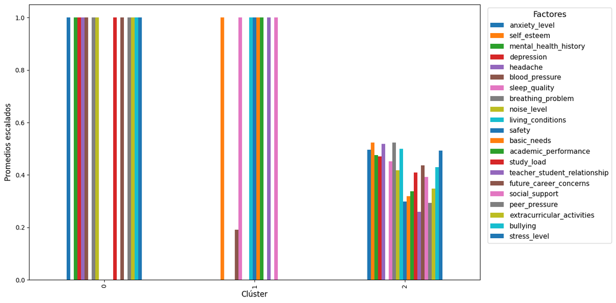

```python
scaler = MinMaxScaler()
escalar_promedios = pd.DataFrame(scaler.fit_transform(promedios), columns=promedios.columns, index=promedios.index)

graficar_barras_promedios(escalar_promedios, ylabel='Promedios escalados')
```

**Gráfico tipo radar**

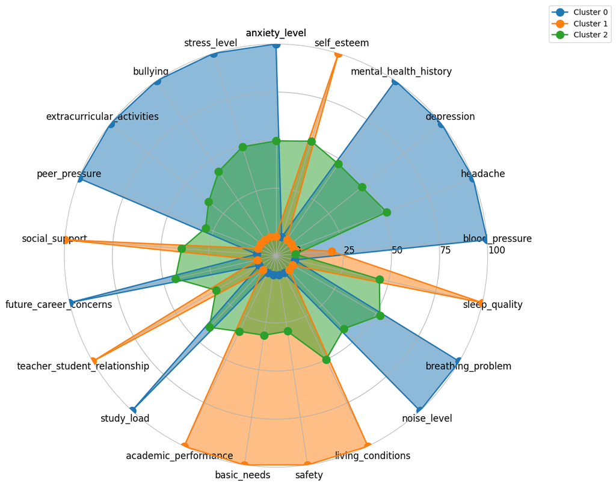

```python
graficar_radar_promedios(escalar_promedios)
```

## Parte 6

- f) Genere k-Medoides con 3 clusters. (Utilice los parámetros que considere más adecuados). Muestre la inercia, el gráfico de barras y el de radar.

> El método de **KMedoides** permite definir la distancia, estos pueden ser:
> - `euclidean` y `manhattan` generalmente suelen tener buenos resultados para la mayoría de casos.
> - `cosine` suele tener buenos resultados cuando los datos son de alta dimensión.
> - `canberra` y `jaccard` suele tener buenos resultados para datos binarios o categóricos.
> - `mahalanobis` suele tener buenos resultados cuando los puntos de datos presentan correlaciones altas.

> El método de **KMedoides** permite definir el algoritmo, estos pueden ser:
> - `pam` más preciso, pero más lento.
> - `alternate` menos preciso, pero más rápido.

```python
# alternate o pam
kmedoids = KMedoids(n_clusters=3, max_iter=100, metric="euclidean", method='pam')
kmedoids.fit(datos_escalados)
```

```
KMedoids(max_iter=100, method='pam', n_clusters=3)
```

**Clusters**

```python
grupos = kmedoids.labels_
grupos
```

```
array([2, 1, 2, ..., 0, 1, 1])
```

**Unir cluster -> df**

```python
datos_cluster = df.copy()
datos_cluster["cluster"] = grupos
datos_cluster.head(7)
```

|  | anxiety_level | self_esteem | mental_health_history | depression | headache | blood_pressure | sleep_quality | breathing_problem | noise_level | living_conditions | ... | academic_performance | study_load | teacher_student_relationship | future_career_concerns | social_support | peer_pressure | extracurricular_activities | bullying | stress_level | cluster |
| --- | --- | --- | --- | --- | --- | --- | --- | --- | --- | --- | --- | --- | --- | --- | --- | --- | --- | --- | --- | --- | --- |
| 0 | 14 | 20 | 0 | 11 | 2 | 1 | 2 | 4 | 2 | 3 | ... | 3 | 2 | 3 | 3 | 2 | 3 | 3 | 2 | 1 | 2 |
| 1 | 15 | 8 | 1 | 15 | 5 | 3 | 1 | 4 | 3 | 1 | ... | 1 | 4 | 1 | 5 | 1 | 4 | 5 | 5 | 2 | 1 |
| 2 | 12 | 18 | 1 | 14 | 2 | 1 | 2 | 2 | 2 | 2 | ... | 2 | 3 | 3 | 2 | 2 | 3 | 2 | 2 | 1 | 2 |
| 3 | 16 | 12 | 1 | 15 | 4 | 3 | 1 | 3 | 4 | 2 | ... | 2 | 4 | 1 | 4 | 1 | 4 | 4 | 5 | 2 | 1 |
| 4 | 16 | 28 | 0 | 7 | 2 | 3 | 5 | 1 | 3 | 2 | ... | 4 | 3 | 1 | 2 | 1 | 5 | 0 | 5 | 1 | 2 |
| 5 | 20 | 13 | 1 | 21 | 3 | 3 | 1 | 4 | 3 | 2 | ... | 2 | 5 | 2 | 5 | 1 | 4 | 4 | 5 | 2 | 1 |
| 6 | 4 | 26 | 0 | 6 | 1 | 2 | 4 | 1 | 1 | 4 | ... | 5 | 1 | 4 | 1 | 3 | 2 | 2 | 1 | 0 | 0 |

7 rows × 22 columns

**Centro clusters**

```python
promedios = datos_cluster.groupby("cluster").mean()
promedios
```

| cluster | anxiety_level | self_esteem | mental_health_history | depression | headache | blood_pressure | sleep_quality | breathing_problem | noise_level | living_conditions | ... | basic_needs | academic_performance | study_load | teacher_student_relationship | future_career_concerns | social_support | peer_pressure | extracurricular_activities | bullying | stress_level |
| --- | --- | --- | --- | --- | --- | --- | --- | --- | --- | --- | --- | --- | --- | --- | --- | --- | --- | --- | --- | --- | --- |
| 0 | 4.309375 | 26.775000 | 0.021875 | 4.646875 | 1.037500 | 2.062500 | 4.390625 | 1.562500 | 1.484375 | 3.543750 | ... | 4.437500 | 4.440625 | 1.518750 | 4.334375 | 1.087500 | 2.862500 | 1.559375 | 1.571875 | 1.043750 | 0.012500 |
| 1 | 17.354651 | 8.232558 | 0.991279 | 20.732558 | 3.875000 | 3.000000 | 1.174419 | 3.790698 | 3.848837 | 1.563953 | ... | 1.563953 | 1.622093 | 3.790698 | 1.494186 | 4.267442 | 0.927326 | 4.296512 | 4.229651 | 4.241279 | 1.901163 |
| 2 | 11.057339 | 18.704128 | 0.444954 | 11.908257 | 2.509174 | 1.623853 | 2.561927 | 2.809633 | 2.557339 | 2.518349 | ... | 2.504587 | 2.456422 | 2.509174 | 2.321101 | 2.518349 | 1.915138 | 2.364679 | 2.490826 | 2.490826 | 1.004587 |

3 rows × 21 columns

**Inercias**

```python
incercia_km(df)
```

```
'intra_clase: 79556.84, inter_clase: 148621.43, inercia_total: 228178.27'
```

**Gráfico de Barras**

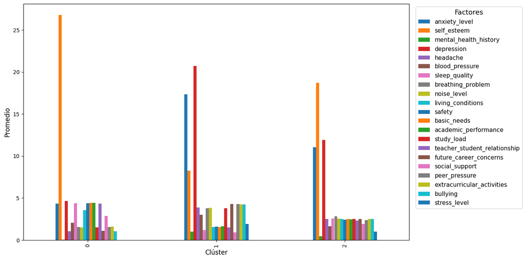

```python
graficar_barras_promedios(promedios, "Clúster", "Promedio", "Factores")
```

**MinMaxScaler**

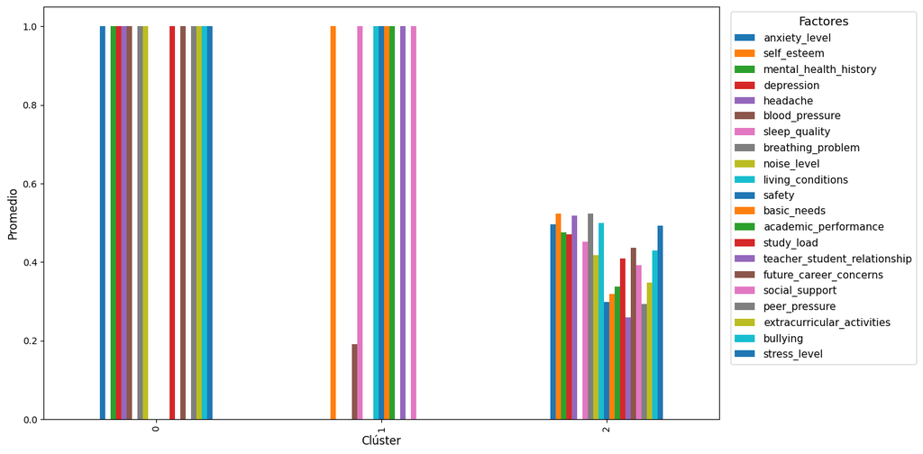

```python
graficar_barras_promedios(escalar_promedios)
```

**Gráfico tipo radar**

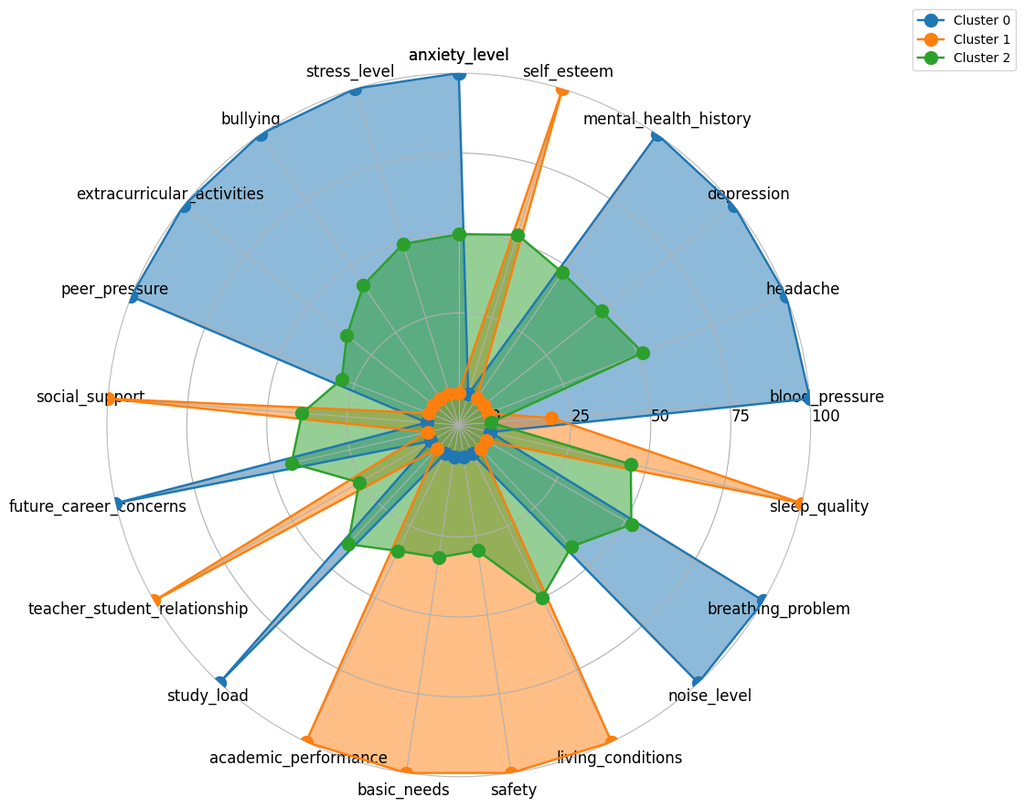

```python
graficar_radar_promedios(escalar_promedios)
```

# Ejercicio 2

[20 puntos] Programe la Jerarquía de Clases que se muestra en la siguiente imágen:

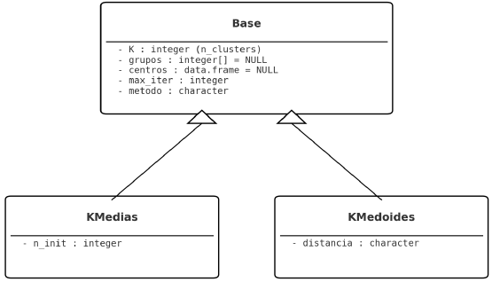

**Clase Base:**

- a) `K`: Número que indica la cantidad de clústeres a formar (`n_clusters`).
- b) `grupos`: Vector que contiene en la entrada respectiva el clúster a los que pertenece cada individuo. (Inicializar con *None*).
- c) `centros`: *data.frame* que tiene el valor promedio de cada variable según el clúster (centreo de gravedad del clúster). (Inicializar con *None*).
- d) `max_iter`: Número que indica la cantidad de iteraciones máximas.
- e) `metodo`: String que indica el algoritmo que va a utilizar. En *K-Medoides* puede ser `alternate` o `pam` y en *K-Medias* puede ser `lloyd` o `elkan`

**KMedias:**

- a) `n_init`: Número que indica la cantidad de inicializadores (Formas Fuertes).

**KMedoides:**

- a) `distancia` : String que indica cuál fórmula de distancia (métrica) va a utilizar para calcular las distancias.

**Métodos:**

- `__init__` : El constructor debe recibir por parámetro los atributos como se observa en el diagrama. Aquellos que se inicializan con *None* no deben recibirse por parámetro.
- `gets`: Todos los atributos deben tener un `get`.
- `sets`: No es necesario definir el `set` para ningún atributo.
- `fit`: el método `fit` debe sobrecargarse para todas las clases. Debe generar el modelo correspondiente al de la clase y modificar los atributos `grupos` y `centros`. En el caso de la clase `CJ` debe también modificar los atributos `distancias` y `agregaciones`.
- `inercias`: retorna en un diccionario la inercia total, la inercia inter-clase y la inercia intra-clase.
- `grafico barra`: retorna el gráfico de barras con el valor promedio de cada variable según el cluster. Debe recibir por parámetro un valor booleano indicando si se quiere estandarizar los centros.
- `grafico radar`: retorna el gráfico radar con el valor promedio de cada variable según el cluster.

**Optativo** [10 puntos] Agregue a la jerarquía anterior la(s) clase(s) necesaria(s) de manera adecuada de forma tal que se incluyan todos los atributos y métodos necesarios para implementar la Clusterización Jerárquica.

↑ Volver al Menú

## **Base:**

- a) `K`: Número que indica la cantidad de clústeres a formar (`n_clusters`).
- b) `grupos`: Vector que contiene en la entrada respectiva el clúster a los que pertenece cada individuo. (Inicializar con *None*).
- c) `centros`: *data.frame* que tiene el valor promedio de cada variable según el clúster (centreo de gravedad del clúster). (Inicializar con *None*).
- d) `max_iter`: Número que indica la cantidad de iteraciones máximas.
- e) `metodo`: String que indica el algoritmo que va a utilizar. En *K-Medoides* puede ser `alternate` o `pam` y en *K-Medias* puede ser `lloyd` o `elkan`

```python
class Base(ABC):
# constructor
  def __init__(self, K, max_iter, metodo):
    self._K = K                  # int (n_clusters)
    self._grupos = None          # data.frame (null)
    self._centros = None         # int[] (null)
    self._max_iter = max_iter    # int
    self._metodo = metodo        # string

# getter
  @property
  def K(self):
      return self._K

  @property
  def grupos(self):
      return self._grupos

  @property
  def centros(self):
      return self._centros

  @property
  def max_iter(self):
      return self._max_iter

  @property
  def metodo(self):
      return self._metodo

# settter
  # No es necesario definir el set para ningún atributo.

# methods
  @abstractmethod
  def fit(self, datos):
    pass # Se implementa en cada clase hija.

  def inercias(self, datos):
    if self.grupos is None or self.centros is None:
      print("Error: El modelo no ha sido entrenado. Entrene el modelo primero.")
      return None

    # El cálculo es el mismo
    distancia_puntos_a_centros = np.linalg.norm(datos.values - self.centros.loc[self.grupos].values, axis=1)
    inercia_intra_clase = np.sum(distancia_puntos_a_centros**2)
    centro_total = datos.values.mean(axis=0)
    distancia_puntos_a_total = np.linalg.norm(datos.values - centro_total, axis=1)
    inercia_total = np.sum(distancia_puntos_a_total**2)
    inercia_inter_clase = inercia_total - inercia_intra_clase

    return {
        'inercia_total': inercia_total,
        'inercia_inter_clase': inercia_inter_clase,
        'inercia_intra_clase': inercia_intra_clase
    }

  @staticmethod
  def graficar_barras_promedios(promedios):
    """
    Grafica un barplot de promedios por clúster.

    Parámetros
    ----------
    promedios : pandas.DataFrame
        DataFrame resultante de agrupar por 'cluster' y promediar.
        - El índice debe ser el nombre/ID del clúster.
        - Las columnas son las variables (materias).
    """
    fig, ax = plt.subplots()  # tamaño por defecto
    no_print = promedios.plot(kind='bar', ax=ax)
    no_print = ax.set_xlabel('Clúster', fontsize=6)
    no_print = ax.set_ylabel('Promedio', fontsize=6)
    no_print = ax.legend(title="Materia", title_fontsize=13, fontsize=11, loc='upper right', bbox_to_anchor=(1.35, 1))
    plt.show()

  @staticmethod
  def graficar_radar_promedios(promedios):
    """
    Grafica un radar chart (polar) para los promedios por clúster.

    Parámetros
    ----------
    promedios : pandas.DataFrame
        DataFrame con índice = clústeres y columnas = variables.
    """
    # Escalado 0-100
    scaler = MinMaxScaler()
    escalar_promedios = pd.DataFrame(
        scaler.fit_transform(promedios),
        columns=promedios.columns,
        index=promedios.index
    )
    escalar_promedios = escalar_promedios * 100
    columnas = escalar_promedios.columns
    N = len(columnas)
    # Ángulos (cerrando el polígono)
    theta = np.linspace(0, 2 * np.pi, N, endpoint=False)
    theta = np.concatenate([theta, [theta[0]]])
    fig, ax = plt.subplots(figsize=(6, 6), subplot_kw={"projection": "polar"})
    no_print = ax.set_theta_zero_location("N")
    no_print = ax.set_theta_direction(-1)
    no_print = ax.set_rlabel_position(90)
    no_print = ax.spines["polar"].set_zorder(1)
    no_print = ax.spines["polar"].set_color("lightgrey")
    # Trazar cada clúster
    for fila in escalar_promedios.index:
        valores = escalar_promedios.loc[fila, columnas].values.tolist()
        valores = valores + [valores[0]]  # cerrar polígono
        no_print = ax.plot(theta, valores, linewidth=1.75, linestyle="solid",
                           label=f"Cluster {fila}", marker="o", markersize=10)
        no_print = ax.fill(theta, valores, alpha=0.50)
    # Ejes y leyendas
    no_print = plt.yticks([0, 25, 50, 75, 100], ["0", "25", "50", "75", "100"], color="black", size=12)
    no_print = plt.ylim(-10, 100)
    no_print = plt.xticks(theta, columnas.to_list() + [columnas[0]], color="black", size=12)
    no_print = plt.legend(loc="upper left", bbox_to_anchor=(1.3, 1.1))
    plt.show()

  def __str__(self):
    inercias = self.__inercias()
    return (f"CJ - Clustering Jerárquico\n"
            f"--------------------------\n"
            f"Datos: {self.__datos.shape[0]} individuos, {self.__datos.shape[1]} variables\n"
            f"Clusters: {self.__num_cluster}\n"
            f"Algoritmo: {self.__algoritmo}\n"
            f"Agregación: {self.__agregacion}\n"
            f"Inercia total: {inercias['inercia_total']:.2f}\n"
            f"Inercia inter: {inercias['inercia_inter']:.2f}\n"
            f"Inercia intra: {inercias['inercia_intra']:.2f}")
```

## **KMedias:**

- a) `n_init`: Número que indica la cantidad de inicializadores (Formas Fuertes).

```python
class KMedias(Base):
# constructor
  def __init__(self, K, max_iter, n_init, metodo='lloyd'):
    # Llama al constructor de la clase padre
    super().__init__(K=K, max_iter=max_iter, metodo=metodo)
    self._n_init = n_init

# get
  @property
  def n_init(self):
      return self._n_init

# Methods
  def fit(self, datos):

    best_inertia = float('inf')
    best_grupos = None
    best_centros = None

    for i in range(self._n_init):
      # print(f"Entrenando el modelo K-Medias con {self._n_init} inicializaciones y {self.max_iter} iteraciones.")
      centros = datos.sample(self.K).values

      # Inicialización de centros aleatorios (primer paso de la lógica)
      for _ in range(self.max_iter):
        # Asignación
        distancias = np.linalg.norm(datos.values[:, np.newaxis] - centros, axis=2)
        grupos = np.argmin(distancias, axis=1)

        # Actualización de centros (la clave de K-Medias)
        nuevos_centros = np.array([datos.values[grupos == k].mean(axis=0) for k in range(self.K)])

        # Condición de parada
        if np.linalg.norm(nuevos_centros - centros) < 1e-4:
          centros = nuevos_centros
          break
        centros = nuevos_centros

      # Cálculo de inercia para este intento
      current_inertia = np.sum((np.linalg.norm(datos.values - centros[grupos], axis=1))**2)

      # Selección del mejor resultado
      if current_inertia < best_inertia:
        best_inertia = current_inertia
        best_grupos = grupos
        best_centros = centros

    self._grupos = best_grupos
    self._centros = pd.DataFrame(best_centros)
    print("¡Entrenamiento de K-Medias completado!")

# Print
  def __str__(self):
      return f"Numero iteraciones: {self._n_init}"
```

## **KMedoides:**

- a) `distancia` : String que indica cuál fórmula de distancia (métrica) va a utilizar para calcular las distancias.

```python
class KMedoides(Base):
# constructor
  def __init__(self, K, max_iter, distancia='euclidean', metodo='pam'):
    super().__init__(K=K, max_iter=max_iter, metodo=metodo)
    self._distancia = distancia

# get
  @property
  def distancia(self):
      return self._distancia

# Methods
  def fit(self, datos):
    print(f"Entrenando el modelo K-Medoides con la distancia: '{self.distancia}', {self.max_iter} iteraciones y el método: '{self.metodo}'.")

    # best_inertia = float('inf')
    # best_grupos = None
    # best_centros_indices = None

    # Convierte el DataFrame a un array de NumPy al inicio
    datos_np = datos.values

    # 1. Inicialización: Se eligen K puntos de datos como medoides iniciales.
    indices_medoides = np.random.choice(len(datos_np), self.K, replace=False)
    medoides = datos_np[indices_medoides]

    for i in range(self.max_iter):
      # 2. Asignación: Se asigna cada punto al medoide más cercano.
      distancias = np.linalg.norm(datos_np[:, np.newaxis] - medoides, axis=2)
      grupos = np.argmin(distancias, axis=1)

      # 3. Actualización de medoides (la clave de K-Medoides)
      medoides_actualizados = medoides.copy()
      for k in range(self.K):
        puntos_en_grupo = datos_np[grupos == k]

        if len(puntos_en_grupo) > 0:
          # Encontrar el nuevo medoide
          distancias_dentro_grupo = np.sum(np.linalg.norm(puntos_en_grupo[:, np.newaxis] - puntos_en_grupo, axis=2), axis=1)
          nuevo_medoide_idx = np.argmin(distancias_dentro_grupo)
          medoides_actualizados[k] = puntos_en_grupo[nuevo_medoide_idx]

        # 4. Condición de Parada
        if np.array_equal(medoides_actualizados, medoides):
          # print(f"Los medoides se han estabilizado en la iteración {i+1}. Terminando...")
          break

        medoides = medoides_actualizados

    # Guardar el mejor resultado
    self._grupos = grupos
    self._centros = pd.DataFrame(medoides, columns=datos.columns)
    print("¡Entrenamiento de K-Medoides completado!")


# Print
  def __str__(self):
      return f"distancia: {self._distancia}"
```

```python
def prepro_cod_scalar(datos, is_dummy=True, escalar=True):
    df_copy = datos.copy()
    if is_dummy:
      num_df = df_copy.select_dtypes(include=[np.number])
      cat_df = df_copy.select_dtypes(exclude=[np.number])

      if not cat_df.empty:
          cat_df = pd.get_dummies(cat_df).astype(int)
          df_copy = pd.concat([num_df, cat_df], axis=1)
      else:
          df_copy = num_df

      return df_copy
    # Puedes elegir entre StandardScaler o MinMaxScaler
    if escalar:
      df_scalar = StandardScaler().fit_transform(df_copy)
      df_scalar = pd.DataFrame(df_scalar)
      df_scalar.columns = df_copy.columns
      df_scalar.index = df_copy.index
    return df_scalar
```

```python
df = pd.read_csv('Estudiantes_Categoricas.csv', delimiter = ';', decimal = ",", index_col = 0)
df = df.drop(columns=['Genero','Conducta'])
```

## **Implementación KMedias**

```python
datos_escalados = prepro_cod_scalar(df)
# datos_escalados = datos_escalados.drop(columns=['Conducta','Genero_F', 'Genero_M'])
datos_escalados.head()
```

|  | Matematicas | Ciencias | Espanol | Historia | EdFisica |
| --- | --- | --- | --- | --- | --- |
| Lucia | 7.0 | 6.5 | 9.2 | 8.6 | 8.0 |
| Pedro | 7.5 | 9.4 | 7.3 | 7.0 | 7.0 |
| Ines | 7.6 | 9.2 | 8.0 | 8.0 | 7.5 |
| Luis | 5.0 | 6.5 | 6.5 | 7.0 | 9.0 |
| Andres | 6.0 | 6.0 | 7.8 | 8.9 | 7.3 |

```python
modelo_kmeans = KMedias(K=4, max_iter=100, n_init=10)
modelo_kmeans.fit(datos_escalados)
```

```
¡Entrenamiento de K-Medias completado!
```

**Clusters**

```python
gruposKmedias = modelo_kmeans.grupos
gruposKmedias
# promedios = datos_cluster.groupby("cluster").mean()
```

```
array([2, 3, 3, 1, 0, 3, 0, 3, 1, 2])
```

**Unir Cluster a Data.Frame**

```python
# datos_cluster = datos_escalados.copy()
datos_cluster = df.copy()
datos_cluster["cluster"] = gruposKmedias
datos_cluster
```

|  | Matematicas | Ciencias | Espanol | Historia | EdFisica | cluster |
| --- | --- | --- | --- | --- | --- | --- |
| Lucia | 7.0 | 6.5 | 9.2 | 8.6 | 8.0 | 2 |
| Pedro | 7.5 | 9.4 | 7.3 | 7.0 | 7.0 | 3 |
| Ines | 7.6 | 9.2 | 8.0 | 8.0 | 7.5 | 3 |
| Luis | 5.0 | 6.5 | 6.5 | 7.0 | 9.0 | 1 |
| Andres | 6.0 | 6.0 | 7.8 | 8.9 | 7.3 | 0 |
| Ana | 7.8 | 9.6 | 7.7 | 8.0 | 6.5 | 3 |
| Carlos | 6.3 | 6.4 | 8.2 | 9.0 | 7.2 | 0 |
| Jose | 7.9 | 9.7 | 7.5 | 8.0 | 6.0 | 3 |
| Sonia | 6.0 | 6.0 | 6.5 | 5.5 | 8.7 | 1 |
| Maria | 6.8 | 7.2 | 8.7 | 9.0 | 7.0 | 2 |

**Centro Clusters**

```python
promedios = datos_cluster.groupby("cluster").mean()
promedios
```

| cluster | Matematicas | Ciencias | Espanol | Historia | EdFisica |
| --- | --- | --- | --- | --- | --- |
| 0 | 6.15 | 6.200 | 8.000 | 8.95 | 7.25 |
| 1 | 5.50 | 6.250 | 6.500 | 6.25 | 8.85 |
| 2 | 6.90 | 6.850 | 8.950 | 8.80 | 7.50 |
| 3 | 7.70 | 9.475 | 7.625 | 7.75 | 6.75 |

**Inercias**

```python
modelo_kmeans.inercias(df)
```

```
{'inercia_total': 57.21399999999999,
 'inercia_inter_clase': 51.718999999999994,
 'inercia_intra_clase': 5.495}
```

**Gráfico de Barras**

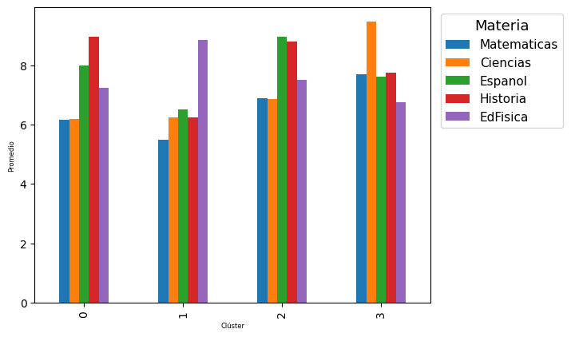

```python
modelo_kmeans.graficar_barras_promedios(promedios)
```

**MinMaxScaler**

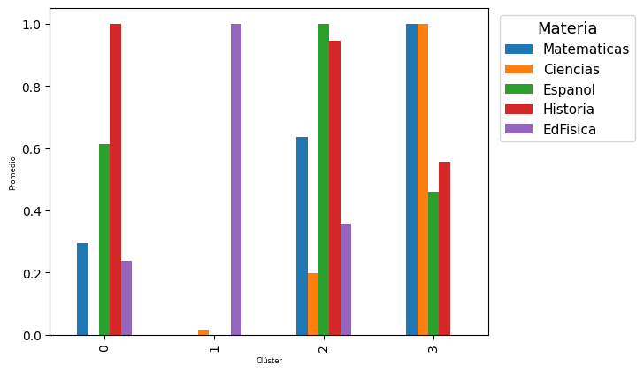

```python
scaler = MinMaxScaler()
escalar_promedios = pd.DataFrame(scaler.fit_transform(promedios), columns=promedios.columns, index=promedios.index)

modelo_kmeans.graficar_barras_promedios(escalar_promedios)
```

**Gráfico tipo Araña**

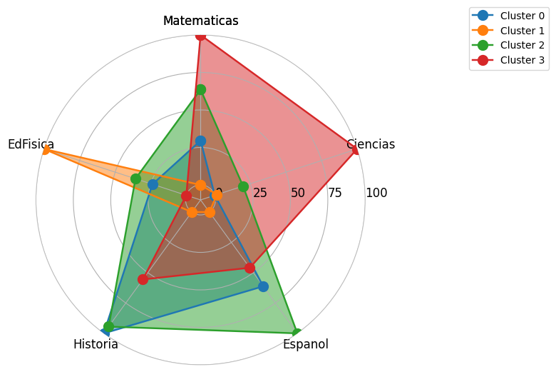

```python
# scaler = MinMaxScaler()
# escalar_promedios = pd.DataFrame(scaler.fit_transform(promedios), columns=promedios.columns, index=promedios.index)
# escalar_promedios = escalar_promedios * 100
modelo_kmeans.graficar_radar_promedios(promedios)
```

## **Implementación KMedoides**

```python
modelo_kmedoides = KMedoides(K=4, max_iter=100, distancia='euclidean', metodo='pam')
modelo_kmedoides.fit(df)
```

```
Entrenando el modelo K-Medoides con la distancia: 'euclidean', 100 iteraciones y el método: 'pam'.
¡Entrenamiento de K-Medoides completado!
```

**Clusters**

```python
gruposKmedoides = modelo_kmedoides.grupos
gruposKmedoides
```

```
array([2, 1, 0, 3, 3, 0, 3, 0, 3, 2])
```

**Unir cluster a data.frame**

```python
datos_cluster = df.copy()
datos_cluster["cluster"] = gruposKmedoides
datos_cluster
```

|  | Matematicas | Ciencias | Espanol | Historia | EdFisica | cluster |
| --- | --- | --- | --- | --- | --- | --- |
| Lucia | 7.0 | 6.5 | 9.2 | 8.6 | 8.0 | 2 |
| Pedro | 7.5 | 9.4 | 7.3 | 7.0 | 7.0 | 1 |
| Ines | 7.6 | 9.2 | 8.0 | 8.0 | 7.5 | 0 |
| Luis | 5.0 | 6.5 | 6.5 | 7.0 | 9.0 | 3 |
| Andres | 6.0 | 6.0 | 7.8 | 8.9 | 7.3 | 3 |
| Ana | 7.8 | 9.6 | 7.7 | 8.0 | 6.5 | 0 |
| Carlos | 6.3 | 6.4 | 8.2 | 9.0 | 7.2 | 3 |
| Jose | 7.9 | 9.7 | 7.5 | 8.0 | 6.0 | 0 |
| Sonia | 6.0 | 6.0 | 6.5 | 5.5 | 8.7 | 3 |
| Maria | 6.8 | 7.2 | 8.7 | 9.0 | 7.0 | 2 |

**Centro clusteres**

```python
promedios = datos_cluster.groupby("cluster").mean()
promedios
```

| cluster | Matematicas | Ciencias | Espanol | Historia | EdFisica |
| --- | --- | --- | --- | --- | --- |
| 0 | 7.766667 | 9.500 | 7.733333 | 8.0 | 6.666667 |
| 1 | 7.500000 | 9.400 | 7.300000 | 7.0 | 7.000000 |
| 2 | 6.900000 | 6.850 | 8.950000 | 8.8 | 7.500000 |
| 3 | 5.825000 | 6.225 | 7.250000 | 7.6 | 8.050000 |

**Inercias**

```python
modelo_kmedoides.inercias(df)
```

```
{'inercia_total': 57.21399999999999,
 'inercia_inter_clase': 28.59399999999999,
 'inercia_intra_clase': 28.62}
```

**Grafico de Barras**

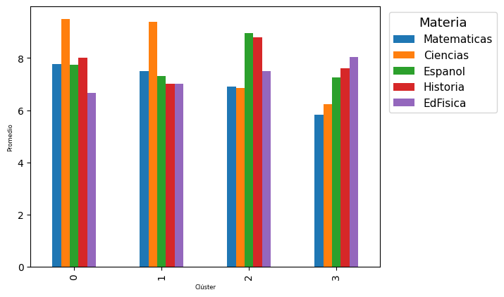

```python
modelo_kmedoides.graficar_barras_promedios(promedios)
```

**MinMaxScaler**

```python
scaler = MinMaxScaler()
escalar_promedios2 = pd.DataFrame(scaler.fit_transform(promedios), columns=promedios.columns, index=promedios.index)
```

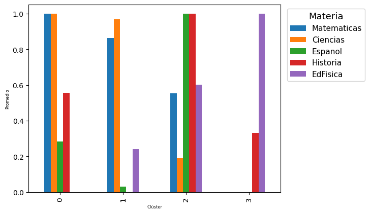

```python
modelo_kmedoides.graficar_barras_promedios(escalar_promedios2)
```

**Grafico de Radar**

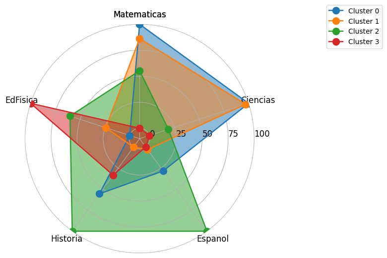

```python
modelo_kmedoides.graficar_radar_promedios(escalar_promedios2)
```

## **Optional**

- [10 puntos] Agregue a la jerarquía anterior la(s) clase(s) necesaria(s) de manera adecuada de forma tal que se incluyan todos los atributos y métodos necesarios para implementar la Clusterización Jerárquica.

```python
class CJ(Base):
  def __init__(self, K, max_iter, distancia='euclidean', metodo='ward'):
    super().__init__(K=K, max_iter=max_iter, metodo=metodo)
    self._distancia = distancia
    self._datos_cluster = None
    self._calculo_distancias = None
    self._agregacion = None
    self._matriz_distancias = None
    self._matriz_agregaciones = None

# get
  @property
  def distancia(self):
      return self._distancia
  @property
  def datos_cluster(self):
      return self._datos_cluster
  @property
  def calculo_distancias(self):
      return self._calculo_distancias
  @property
  def matriz_distancias(self):
      return self._matriz_distancias
  @property
  def agregacion(self):
      return self._agregacion
  @property
  def matriz_agregaciones(self):
      return self._matriz_agregaciones

# Methods
  def fit(self, datos):
    # Calcular matriz de distancias
    if self._distancia == 'euclidean': # Corrected to use self._distancia
      self._matriz_distancias = pdist(datos.values, metric = self._distancia)
    elif self._distancia == 'manhattan': # Corrected to use self._distancia
      self._matriz_distancias = pdist(datos.values, metric = self._distancia)
    elif self._distancia == 'cosine': # Corrected to use self._distancia
      self._matriz_distancias = pdist(datos.values, metric = self._distancia)
    elif self._distancia == 'correlation': # Corrected to use self._distancia
      self._matriz_distancias = pdist(datos.values, metric = self._distancia)
    else:
        raise ValueError(f"Algoritmo de distancia '{self._distancia}' no soportado.")


    # Calcular matriz de agregaciones
    if self._metodo == 'ward':
      self._matriz_agregaciones = linkage(self._matriz_distancias, method=self._metodo)
    elif self._metodo == 'single':
      self._matriz_agregaciones = linkage(self._matriz_distancias, method=self._metodo)
    elif self._metodo == 'complete':
      self._matriz_agregaciones = linkage(self._matriz_distancias, method=self._metodo)
    elif self._metodo == 'average':
      self._matriz_agregaciones = linkage(self._matriz_distancias, method=self._metodo)
    else:
        raise ValueError(f"Método de agregación '{self._metodo}' no soportado.")


    # Obtener grupos y ajustar indicea
    self._grupos = fcluster(self._matriz_agregaciones, self._K, criterion='maxclust')
    self._grupos = self._grupos - 1  # Para que empiece en 0

    # Calcular centros
    datos_con_grupos = datos.copy()
    datos_con_grupos['cluster'] = self._grupos
    self._centros = datos_con_grupos.groupby('cluster').mean()

    print("¡Entrenamiento de Cluster Jerarquico completado!")

# Method Graficos
  def grafico_dendrograma(self, figsize=(15, 5)):
    if self._matriz_agregaciones is None:
      print("Error: El modelo no ha sido entrenado. Entrene el modelo primero.")
      return

    plt.figure(figsize=figsize) # Set the figure size here
    dendrogram(self._matriz_agregaciones)
    plt.title('Dendrograma de Clusterización Jerárquica')
    plt.xlabel('Puntos de datos')
    plt.ylabel('Distancia')
    plt.show()


# Print
  def __str__(self):
      return f"distancia: {self._distancia}"
```

## **Implementación Cluster Jerárquico**

```python
modelo_cj = CJ(K=3, max_iter=0,  distancia='euclidean', metodo='ward')
modelo_cj.fit(df)
```

```
¡Entrenamiento de Cluster Jerarquico completado!
```

```python
print(f"Número de clústeres deseado: {modelo_cj.K}")
```

```
Número de clústeres deseado: 3
```

```python
print(f"Método: {modelo_cj.distancia}")
modelo_cj.matriz_distancias
```

```
Método: euclidean
```

```
array([3.97869325, 3.1144823 , 3.85356977, 1.94679223, 3.88715835,
       1.51657509, 4.27784993, 4.31740663, 1.39283883, 1.33790882,
       4.39317653, 4.2142615 , 1.24096736, 3.91024296, 1.5132746 ,
       4.4260592 , 3.36005952, 4.42153819, 3.7       , 1.13578167,
       3.26496554, 1.68522995, 4.76864761, 2.52586619, 3.0724583 ,
       5.11272921, 3.4394767 , 5.44518136, 1.89472953, 4.07062649,
       4.20238028, 0.65574385, 4.45982062, 3.9       , 1.72916165,
       3.77226722, 0.55677644, 5.36003731, 3.0016662 , 4.04722127,
       4.2       , 1.08627805, 5.64269439, 3.3015148 , 4.69680743])
```

```python
print(f"Agregación: {modelo_cj.metodo}")
modelo_cj.matriz_agregaciones
```

```
Agregación: ward
```

```
array([[ 5.        ,  7.        ,  0.55677644,  2.        ],
       [ 4.        ,  6.        ,  0.65574385,  2.        ],
       [ 1.        ,  2.        ,  1.33790882,  2.        ],
       [ 0.        ,  9.        ,  1.39283883,  2.        ],
       [10.        , 12.        ,  1.71172428,  4.        ],
       [ 3.        ,  8.        ,  1.89472953,  2.        ],
       [11.        , 13.        ,  1.98620241,  4.        ],
       [15.        , 16.        ,  6.13038879,  6.        ],
       [14.        , 17.        ,  7.86837552, 10.        ]])
```

```python
modelo_cj.centros
```

| cluster | Matematicas | Ciencias | Espanol | Historia | EdFisica |
| --- | --- | --- | --- | --- | --- |
| 0 | 7.700 | 9.475 | 7.625 | 7.750 | 6.750 |
| 1 | 5.500 | 6.250 | 6.500 | 6.250 | 8.850 |
| 2 | 6.525 | 6.525 | 8.475 | 8.875 | 7.375 |

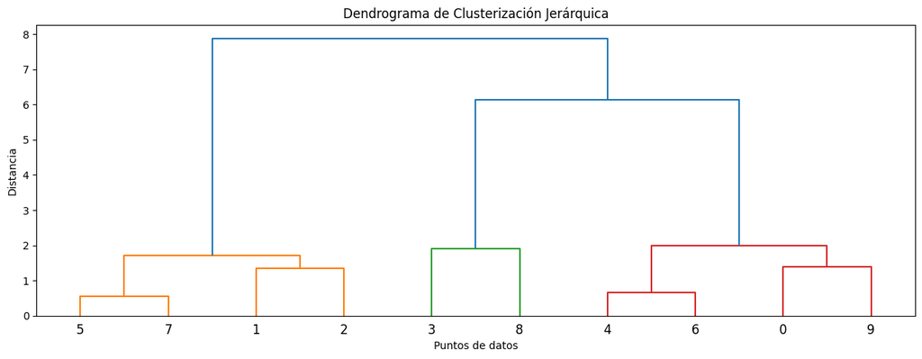

```python
modelo_cj.grafico_dendrograma()
```

```python
modelo_cj.grupos
```

```
array([2, 0, 0, 1, 2, 0, 2, 0, 1, 2], dtype=int32)
```

```python
promedios = modelo_cj.centros
promedios
```

| cluster | Matematicas | Ciencias | Espanol | Historia | EdFisica |
| --- | --- | --- | --- | --- | --- |
| 0 | 7.700 | 9.475 | 7.625 | 7.750 | 6.750 |
| 1 | 5.500 | 6.250 | 6.500 | 6.250 | 8.850 |
| 2 | 6.525 | 6.525 | 8.475 | 8.875 | 7.375 |

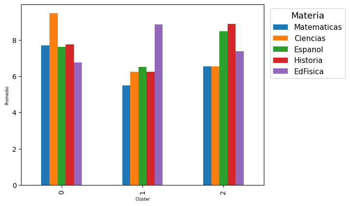

```python
modelo_cj.graficar_barras_promedios(promedios)
```

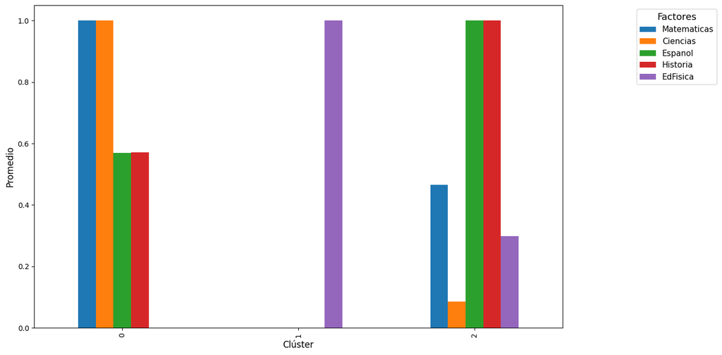

```python
scaler = MinMaxScaler()
promedios_escalados = pd.DataFrame(scaler.fit_transform(promedios), columns=promedios.columns, index=promedios.index)
graficar_barras_promedios(promedios_escalados)
```

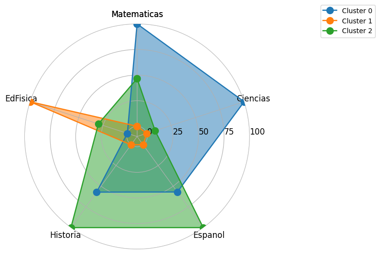

```python
modelo_cj.graficar_radar_promedios(promedios)
```

```python
modelo_cj.inercias(df)
```

```
{'inercia_total': 57.21399999999999,
 'inercia_inter_clase': 49.74649999999999,
 'inercia_intra_clase': 7.4675}
```